# ED231D HANDOUT 1: Introduction to R for Multilevel Modeling

Author

Jordan Rickles

Published

January 14, 2025

# R Walkthrough #1

This handout illustrates how to use R to estimate a basic unconditional multilevel model. For the illustration, the handout follows the example in Chapter 4 of the Raudenbush & Bryk (2002) textbook, which uses the 1982 High School & Beyond (HS&B) Survey data. Throughout the handout, I use “R&B” to refer to the textbook.

**Caution**

You should already have a basic familiarity with the R statistical programming language before using this handout. The UCLA Statistical Consulting group has an [intro to R seminar available online](https://stats.oarc.ucla.edu/r/seminars/intro/) if you need to become familiar with R.

## 1. Getting Started

To get started, we need to load some R packages and the HS&B data we’ll use for the illustrations.

```r
# clear the R environment just in case there are things loaded that we don't want
# (start with a clean slate)
rm(list=ls())

# load packages
library("lme4") # the primary package we'll use for estimating multilevel models
library("merTools") # package that includes the HS&B data we'll use
library("lmerTest") # another package to add functionality to lme4
library("tidyverse") # optional package useful for data processing
library("skimr") # optional package useful for summarizing data file contents
library("vtable") # optional package useful for creating tables
```

**Note**

If you have not already installed these packages, you will first have to install them before loading the libraries.

## 2. Exploring the Data

Let’s start by taking a look at the HS&B data.

**Note**

By loading the `merTools` package, you now have access to the HS&B data used in the R&B textbook. The data are in a data frame named `hsb`.

```r
# summary of the data file and variables
skim(hsb)
```

Data summary

| Name | hsb |
| --- | --- |
| Number of rows | 7185 |
| Number of columns | 8 |
| _______________________ |  |
| Column type frequency: |  |
| character | 1 |
| numeric | 7 |
| ________________________ |  |
| Group variables | None |

**Variable type: character**

| skim_variable | n_missing | complete_rate | min | max | empty | n_unique | whitespace |
| --- | --- | --- | --- | --- | --- | --- | --- |
| schid | 0 | 1 | 4 | 4 | 0 | 160 | 0 |

**Variable type: numeric**

| skim_variable | n_missing | complete_rate | mean | sd | p0 | p25 | p50 | p75 | p100 | hist |
| --- | --- | --- | --- | --- | --- | --- | --- | --- | --- | --- |
| minority | 0 | 1 | 0.27 | 0.45 | 0.00 | 0.00 | 0.00 | 1.00 | 1.00 | ▇▁▁▁▃ |
| female | 0 | 1 | 0.53 | 0.50 | 0.00 | 0.00 | 1.00 | 1.00 | 1.00 | ▇▁▁▁▇ |
| ses | 0 | 1 | 0.00 | 0.78 | -3.76 | -0.54 | 0.00 | 0.60 | 2.69 | ▁▁▇▇▁ |
| mathach | 0 | 1 | 12.75 | 6.88 | -2.83 | 7.28 | 13.13 | 18.32 | 24.99 | ▂▆▇▇▆ |
| size | 0 | 1 | 1056.86 | 604.17 | 100.00 | 565.00 | 1016.00 | 1436.00 | 2713.00 | ▇▇▆▂▂ |
| schtype | 0 | 1 | 0.49 | 0.50 | 0.00 | 0.00 | 0.00 | 1.00 | 1.00 | ▇▁▁▁▇ |
| meanses | 0 | 1 | 0.01 | 0.41 | -1.19 | -0.32 | 0.04 | 0.33 | 0.83 | ▁▃▆▇▃ |

This confirms that we have the same number of students (7,185) and schools (160) as the data used in Chapter 4 of R&B. But it looks like the variable in the data file named `schtype` is called `sector` in the book. We should rename the variable to be consistent with the book.

```r
hsb <- hsb %>% rename(sector = schtype)
```

Now let’s create a school-level file to get a better sense of the school-level data.

```r
# create school-level file for reference
hsb.s <- hsb %>%
  group_by(schid) %>%
  summarize(
    meanach = mean(mathach),
    size = mean(size),
    sector = mean(sector),
    meanses = mean(meanses),
    schn = n()
  )

summary(hsb.s)
```

```
    schid              meanach           size            sector
 Length:160         Min.   : 4.24   Min.   : 100.0   Min.   :0.0000
 Class :character   1st Qu.:10.47   1st Qu.: 588.5   1st Qu.:0.0000
 Mode  :character   Median :12.90   Median :1061.0   Median :0.0000
                    Mean   :12.62   Mean   :1097.8   Mean   :0.4375
                    3rd Qu.:14.65   3rd Qu.:1526.0   3rd Qu.:1.0000
                    Max.   :19.72   Max.   :2713.0   Max.   :1.0000
    meanses                schn
 Min.   :-1.1880000   Min.   :14.00
 1st Qu.:-0.3012500   1st Qu.:35.00
 Median : 0.0345000   Median :47.00
 Mean   :-0.0001875   Mean   :44.91
 3rd Qu.: 0.3200000   3rd Qu.:54.00
 Max.   : 0.8310000   Max.   :67.00
```

```r
table(hsb.s$sector)
```

```
 0  1
90 70
```

We’ve confirmed that there are 90 public schools (sector = 0) and 70 Catholic schools (sector = 1), which matches what’s in Chapter 4. Looking at the summary for `schn`, we can also see that there are about 45 students per school on average.

Now let’s try to recreate the summary statistics in Table 4.1.

```r
st(hsb, vars = c("mathach", "ses"),
   numformat = formatfunc(digits = 2, nsmall = 2),
   title = "Replicaiton of summary statistics in Table 4.1: student-level variables")
```

Replicaiton of summary statistics in Table 4.1: student-level variables

| Variable | N | Mean | Std. Dev. | Min | Pctl. 25 | Pctl. 75 | Max |
| --- | --- | --- | --- | --- | --- | --- | --- |
| mathach | 7185 | 12.75 | 6.88 | -2.83 | 7.28 | 18.32 | 24.99 |
| ses | 7185 | 0.00014 | 0.78 | -3.76 | -0.54 | 0.60 | 2.69 |

```r
st(hsb.s, vars = c("sector", "meanses"),
   numformat = formatfunc(digits = 2, nsmall = 2),
   title = "Replicaiton of summary statistics in Table 4.1: school-level variables")
```

Replicaiton of summary statistics in Table 4.1: school-level variables

| Variable | N | Mean | Std. Dev. | Min | Pctl. 25 | Pctl. 75 | Max |
| --- | --- | --- | --- | --- | --- | --- | --- |
| sector | 160 | 0.44 | 0.50 | 0.00 | 0.00 | 1.00 | 1.00 |
| meanses | 160 | -0.00019 | 0.41 | -1.19 | -0.30 | 0.32 | 0.83 |

## 3. The One-Way ANOVA with Random Effects

We’ll get introduced to using the `lme4` package by replicating the one-way ANOVA example in Chapter 4 of the R&B textbook. This model is also called an unconditional hierarchical linear model. With this model, we’ll estimate the overall population mean ($\gamma_{00}$), the within-school variance component ($\sigma^2$), and the between-school variance component ($\tau_{00}$).

```r
# estimate model and save results as m1
m1 <- lmer(mathach ~ 1 + (1 | schid), data = hsb)

# view summary of the model results
summary(m1)
```

```
Linear mixed model fit by REML. t-tests use Satterthwaite's method [
lmerModLmerTest]
Formula: mathach ~ 1 + (1 | schid)
   Data: hsb

REML criterion at convergence: 47116.8

Scaled residuals:
    Min      1Q  Median      3Q     Max
-3.0631 -0.7539  0.0267  0.7606  2.7426

Random effects:
 Groups   Name        Variance Std.Dev.
 schid    (Intercept)  8.614   2.935
 Residual             39.148   6.257
Number of obs: 7185, groups:  schid, 160

Fixed effects:
            Estimate Std. Error       df t value Pr(>|t|)
(Intercept)  12.6370     0.2444 156.6473   51.71   <2e-16 ***
---
Signif. codes:  0 '***' 0.001 '**' 0.01 '*' 0.05 '.' 0.1 ' ' 1
```

The model summary has the same results as in Table 4.2 of the R&B textbook:

- Average school mean, $\gamma_{00}$ = 12.64 (SE = 0.24)
- School mean variance component, $\tau_{00}$ = 8.61
- Level-1 variance component, $\sigma^2$ = 39.15

However, the `lmer` output does not include the Chi-square test for the random effect term that is reported in Table 4.2. We can get something similar, a likelihood ratio test, with the following R code.

```r
rand(m1)
```

```
ANOVA-like table for random-effects: Single term deletions

Model:
mathach ~ (1 | schid)
            npar logLik   AIC    LRT Df Pr(>Chisq)
<none>         3 -23558 47123
(1 | schid)    2 -24052 48107 986.12  1  < 2.2e-16 ***
---
Signif. codes:  0 '***' 0.001 '**' 0.01 '*' 0.05 '.' 0.1 ' ' 1
```

This test provides evidence that there is statistically significant between-school variation. Or put differently, a model with school-level random effects fits the data better than a model without the random effects.

## 4. Extracting Specific Elements from the Model Results

In the future, it might be useful to pull out specific elements of the model results. The following code illustrates how to do that for some commonly used elements.

```r
# the fixed effects results
summary(m1)$coef
```

```
            Estimate Std. Error       df  t value      Pr(>|t|)
(Intercept) 12.63697  0.2443936 156.6473 51.70747 2.344849e-100
```

```r
# or if you just want to pull out the fixed effect point estimates
summary(m1)$coef[,1]
```

```
[1] 12.63697
```

```r
fixef(m1)
```

```
(Intercept)
   12.63697
```

```r
# the variance components
as.data.frame(VarCorr(m1))
```

```
       grp        var1 var2      vcov    sdcor
1    schid (Intercept) <NA>  8.614025 2.934966
2 Residual        <NA> <NA> 39.148322 6.256862
```

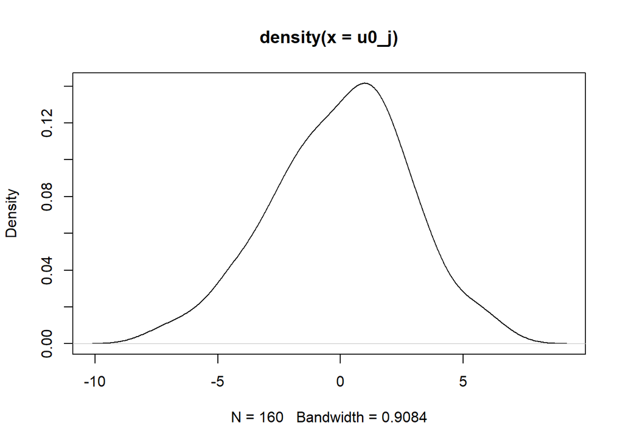

```r
# save each school's estimated random effect
u0_j <- ranef(m1)$schid[,1]
plot(density(u0_j))
```

```r
summary(u0_j)
```

```
   Min. 1st Qu.  Median    Mean 3rd Qu.    Max.
-7.4028 -1.9058  0.2344  0.0000  1.8262  6.4778
```

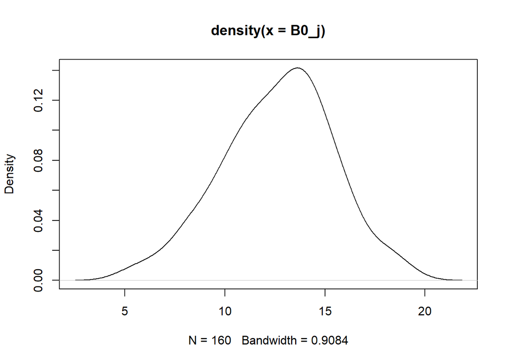

```r
# save each school's estimated intercept (mean math score)
B0_j <- coef(m1)$schid[,1]
plot(density(B0_j))
```

```r
summary(B0_j)
```

```
   Min. 1st Qu.  Median    Mean 3rd Qu.    Max.
  5.234  10.731  12.871  12.637  14.463  19.115
```

## 5. Calculate Auxiliary Statistics

Now let’s use the model estimates to calculate some auxiliary statistics included in Chapater 4 of R&B

```r
# plausible values range for school mean math scores
g00 <- summary(m1)$coef[,1]
tau <- as.data.frame(VarCorr(m1))[1,4]

lb <- g00 - 1.96*sqrt(tau)
ub <- g00 + 1.96*sqrt(tau)

print(c(lb, ub))
```

```
[1]  6.884441 18.389507
```

```r
# intraclass correlation
sig <- as.data.frame(VarCorr(m1))[2,4]

icc <- tau / (tau + sig)
print(icc)
```

```
[1] 0.1803518
```

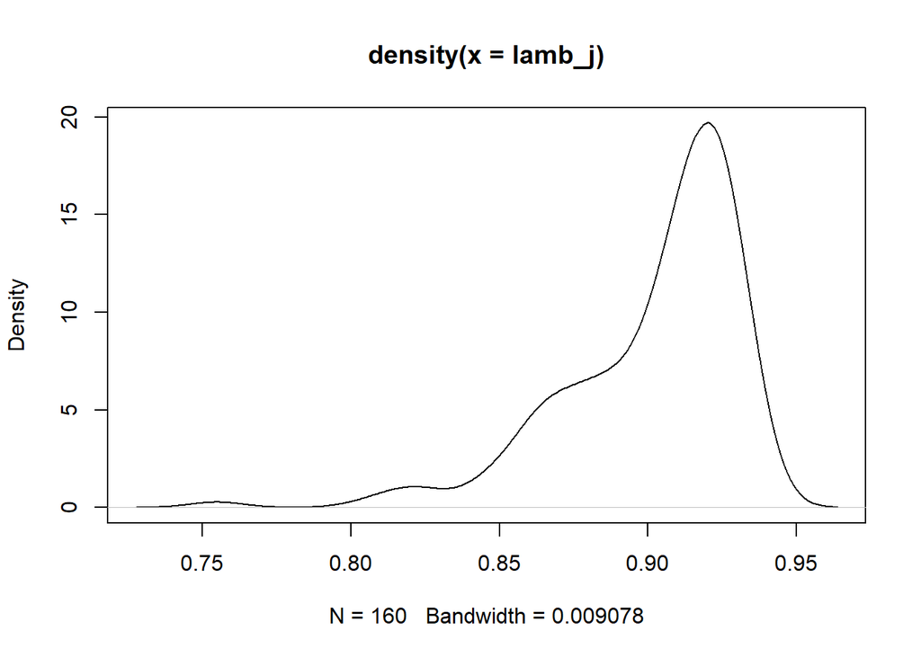

```r
# reliability of the sample mean
n_j <- hsb.s$schn
v_j <- sig / n_j
lamb_j <- tau / (tau + v_j)

plot(density(lamb_j))
```

```r
summary(lamb_j)
```

```
   Min. 1st Qu.  Median    Mean 3rd Qu.    Max.
 0.7549  0.8851  0.9118  0.9014  0.9224  0.9365
```